# Customer Churn Analytics

## Project Overview

This research focus on various factors that may cause customer churn, and how these factors interact with each other. It was important to understand the characteristiics of churned clients and retained clients.

# Data Structure

There was 10,000 customers in the bank's client base, each with 13 features. This project use 10 indepedent variables and 1 depedent variable to generate insights.

### Main interest

I'm interested in determing what features predict customer churn.

### Features that would support investigation

I expect that bank balance, credit score, age,number of products, and estimated salary to have strong effect on churn. while gender, and tenure have little to no effect on churn.

### Account balance distribution

Account balance is bimodal distribution with the highest peak at 0.00, and the second distribution is a normal distribution with a peak between 100k and 150k.

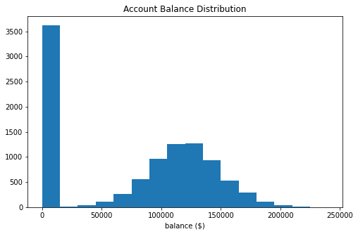

### Proportions of churned and retained clients

20 percent of the client base quit business with the bank and 80% are still doing business with the bank.

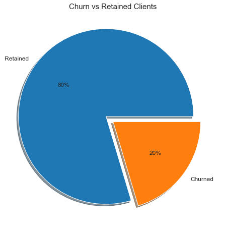

### Proportions of clients by membership status

The proportion of active and dormant members is almost equal, at 52% and 48% respectively. Too close.

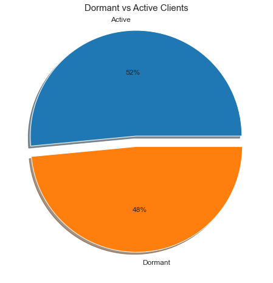

### Number of products vs Churn status

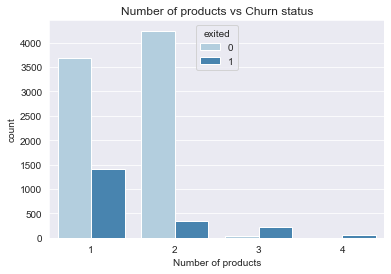

### Bank balance distribution by churn status and number of products

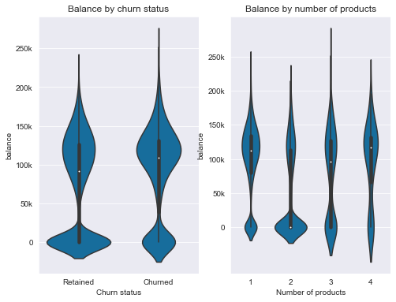

### Age distribution by churn status and number of products

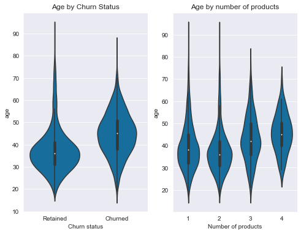

## Conclusion:

All clients with 4 products quit business with the bank. Besides, these clients have a higher account balance compared to those who purchase any other number of products. All clients with 4 products are on average 45 years old.

Majority of the clients who purchased two products have on average 0.00 account balance. A very small proportion of these clients left.

Average age for churned clients is about 45-50 years old while that of retained clients is between 35-40.

48 percent of the clients in this bank are dormant. 20 percent of the clients are no longer doing business with the bank. A huge loss to the bank.

## Recommendation:

The bank should put measures that retain clients above 40 years and those purchasing 3 & 4 products and perhaps investigage what products they purchase. Since most of the churned clients are above 40 years, the bank should come up with products tailored for 40+ years clients.

Any client with account balance above 100K should be under the bank's watch as these are valuable (monetary terms) clients and are more likely to churn.

The bank should dig deeper to understand why clients with high bank balance are more likely to churn. could be poor products by the bank? is it poor customer service?

A large proportion of clients are dormant, the bank should entice them with products and deals that ensure this lot is active.

# END

[output not shown]